# Taller de R básico. Dia 3.

Viacheslav Shalisko

19 de octubre de 2016

### A. Cargar la tabla de datos

#### Estructura de datos (tabla `Datos_del_censo.csv`):

1. *Centro* - código del CU
2. *Especie* - nombre científico
3. *Codigo* - identificador único del arbol
4. *AB* - área basal del árbol (dm<sup>2</sup>)
5. *DTr* - diametro del tronco equivalente (cm)
6. *Alt* - estatura del árbol (m)
7. *DCop* - diametro promedio de la copa (m)
8. *ExcCop* - excentricidad de la copa

```r
arbolado <- read.csv("Materiales/Datos_del_censo.csv")
dim(arbolado)
```

```
## [1] 4785    8
```

```r
head(arbolado)
```

```
##    Centro                    Especie     Codigo    AB  DTr Alt DCop ExcCop
## 1 CUCOSTA       Pithecellobium dulce    C10-3-1 13.21 41.0 9.8 15.4   0.30
## 2 CUCOSTA         Acacia macracantha   C10-3-10  1.91 15.6 4.4  4.7   0.63
## 3 CUCOSTA Pithecellobium lanceolatum  C10-3-100  0.95 11.0 6.4  9.5   0.91
## 4 CUCOSTA         Salix bonplandiana C10-3-1000  0.83 10.3 7.7  4.9   0.20
## 5 CUCOSTA             Tabebuia rosea C10-3-1001  0.28  6.0 2.4  2.0   0.63
## 6 CUCOSTA Pithecellobium lanceolatum C10-3-1002  0.51  8.1 4.1  4.3   0.71
```

```r
tail(arbolado)
```

```
##      Centro                Especie  Codigo    AB  DTr  Alt DCop ExcCop
## 4780 CUCSUR Araucaria heterophylla C9-3-94  6.97 29.8 16.2  5.5   0.50
## 4781 CUCSUR        Ficus benjamina C9-3-95 17.60 47.3 11.5 10.2   0.38
## 4782 CUCSUR       Simarouba glauca C9-3-96  2.63 18.3 11.5  9.4   0.58
## 4783 CUCSUR  Jacaranda mimosifolia C9-3-97 76.95 99.0 20.6 13.0   0.57
## 4784 CUCSUR       Jatropha cordata C9-3-98  2.11 16.4  2.7  3.6   0.23
## 4785 CUCSUR  Jacaranda mimosifolia C9-3-99  7.55 31.0 18.2  5.2   0.77
```

```r
str(arbolado)
```

```
## 'data.frame':    4785 obs. of  8 variables:
##  $ Centro : Factor w/ 4 levels "CUALTOS","CUCIENEGA",..: 3 3 3 3 3 3 3 3 3 3 ...
##  $ Especie: Factor w/ 150 levels "Acacia farnesiana",..: 104 4 105 127 139 105 105 105 139 127 ...
##  $ Codigo : Factor w/ 4780 levels "C10-3-1","C10-3-10",..: 1 2 3 4 5 6 7 8 9 10 ...
##  $ AB     : num  13.21 1.91 0.95 0.83 0.28 ...
##  $ DTr    : num  41 15.6 11 10.3 6 8.1 11.6 9 6 15.8 ...
##  $ Alt    : num  9.8 4.4 6.4 7.7 2.4 4.1 4.4 4.5 4.3 11.6 ...
##  $ DCop   : num  15.4 4.7 9.5 4.9 2 4.3 5.2 4.3 2.5 5.1 ...
##  $ ExcCop : num  0.3 0.63 0.91 0.2 0.63 0.71 0.84 0.84 0.75 0.42 ...
```

```r
levels(arbolado$Centro)
```

```
## [1] "CUALTOS"   "CUCIENEGA" "CUCOSTA"   "CUCSUR"
```

### B. Estadistica descriptiva

#### Resumen

```r
summary(arbolado[,c(1,2,4:8)])
```

```
##        Centro                           Especie           AB
##  CUALTOS  :1828   Quercus resinosa          : 530   Min.   :  0.200
##  CUCIENEGA: 445   Pithecellobium lanceolatum: 501   1st Qu.:  0.950
##  CUCOSTA  :2143   Guazuma ulmifolia         : 329   Median :  2.780
##  CUCSUR   : 369   Fraxinus uhdei            : 278   Mean   :  5.817
##                   Eysenhardtia polystachya  : 245   3rd Qu.:  6.610
##                   Acacia macracantha        : 176   Max.   :456.340
##                   (Other)                   :2726
##       DTr              Alt              DCop            ExcCop
##  Min.   :  5.00   Min.   : 1.500   Min.   : 0.200   Min.   :0.0000
##  1st Qu.: 11.00   1st Qu.: 4.200   1st Qu.: 3.800   1st Qu.:0.3700
##  Median : 18.80   Median : 6.200   Median : 5.500   Median :0.5100
##  Mean   : 22.22   Mean   : 7.121   Mean   : 6.165   Mean   :0.5026
##  3rd Qu.: 29.00   3rd Qu.: 9.100   3rd Qu.: 7.900   3rd Qu.:0.6500
##  Max.   :241.00   Max.   :26.600   Max.   :64.500   Max.   :0.9900
##                   NA's   :46
```

Las funciones básicas de la estadistica descriptiva incluyen:  
1. Promedio y mediana - `mean()`, `median()`  
2. Mínimo, máximo y rango - `min()`, `max()`, `range()`  
3. Desviación estandar y varianza - `sd()`, `var()`  
4. Quantiles y rango intercuartilico - `quantile()`, `IQR()`  
5. Suma y número de elementos - `sum()`, `length()`

```r
summary(arbolado$AB)
```

```
##    Min. 1st Qu.  Median    Mean 3rd Qu.    Max.
##   0.200   0.950   2.780   5.817   6.610 456.300
```

```r
range(arbolado$AB)
```

```
## [1]   0.20 456.34
```

```r
quantile(arbolado$AB)
```

```
##     0%    25%    50%    75%   100%
##   0.20   0.95   2.78   6.61 456.34
```

```r
IQR(arbolado$AB)
```

```
## [1] 5.66
```

```r
var(arbolado$AB)
```

```
## [1] 173.8403
```

```r
sqrt(var(arbolado$AB))
```

```
## [1] 13.18485
```

```r
sd(arbolado$AB)
```

```
## [1] 13.18485
```

```r
probabilidades <- c(0.01,0.05,0.1,0.5,0.9,0.95,0.99)
quantile(arbolado$AB, probs = probabilidades)
```

```
##     1%     5%    10%    50%    90%    95%    99%
##  0.200  0.270  0.410  2.780 12.956 19.630 44.436
```

```r
boxplot.stats(arbolado$AB)$stats
```

```
## [1]  0.20  0.95  2.78  6.61 15.00
```

```r
boxplot.stats(arbolado$AB, coef = 3)$stats
```

```
## [1]  0.20  0.95  2.78  6.61 23.52
```

### C. Algunas funciones de control

#### Estadistica por grupos

```r
aggregate(arbolado$AB ~ arbolado$Centro, FUN = sum)
```

```
##   arbolado$Centro arbolado$AB
## 1         CUALTOS     8521.96
## 2       CUCIENEGA     3478.53
## 3         CUCOSTA    12647.99
## 4          CUCSUR     3184.82
```

```r
aggregate(arbolado$AB ~ arbolado$Centro, FUN = length)
```

```
##   arbolado$Centro arbolado$AB
## 1         CUALTOS        1828
## 2       CUCIENEGA         445
## 3         CUCOSTA        2143
## 4          CUCSUR         369
```

```r
aggregate(arbolado$AB ~ arbolado$Centro, FUN = mean)
```

```
##   arbolado$Centro arbolado$AB
## 1         CUALTOS    4.661904
## 2       CUCIENEGA    7.816921
## 3         CUCOSTA    5.902002
## 4          CUCSUR    8.630949
```

```r
aggregate(arbolado$AB ~ arbolado$Centro, FUN = range)
```

```
##   arbolado$Centro arbolado$AB.1 arbolado$AB.2
## 1         CUALTOS          0.20        114.36
## 2       CUCIENEGA          0.23         77.44
## 3         CUCOSTA          0.20        456.34
## 4          CUCSUR          0.21        419.84
```

#### Estadistica por columnas y/o grupos

El grupo de funciones apply permite realizar operaciones de forma cíclica sin necesidad de definir un ciclo de manera formal:  
1. `lapply()` - aplicar una función a cada elemento de una lista, resultado es una lista de mismo largo que lista de entrada  
2. `sapply()` - lo mismo que `lapply()`, pero con resultado simplificado (vector, matriz o array)  
3. `apply()` - aplicar una función sobre dimensiones de un matriz de datos  
4. `tapply()` - aplicar una función sobre grupos definidos en un vector, similar a `aggregate()`  
5. `mapply()` - versión multivariante de `tapply()`

##### Compara `tapply()` y `aggregate()`

```r
tapply(arbolado$AB, arbolado$Centro, FUN = mean)
```

```
##   CUALTOS CUCIENEGA   CUCOSTA    CUCSUR
##  4.661904  7.816921  5.902002  8.630949
```

```r
aggregate(arbolado$AB ~ arbolado$Centro, FUN = mean)
```

```
##   arbolado$Centro arbolado$AB
## 1         CUALTOS    4.661904
## 2       CUCIENEGA    7.816921
## 3         CUCOSTA    5.902002
## 4          CUCSUR    8.630949
```

##### Compara `lapply()` y `sapply()`

```r
lapply(arbolado[,4:8],sd,na.rm = TRUE)
```

```
## $AB
## [1] 13.18485
##
## $DTr
## [1] 15.71243
##
## $Alt
## [1] 3.847538
##
## $DCop
## [1] 3.352365
##
## $ExcCop
## [1] 0.2009095
```

```r
sapply(arbolado[,4:8],sd,na.rm = TRUE)
```

```
##         AB        DTr        Alt       DCop     ExcCop
## 13.1848514 15.7124261  3.8475377  3.3523652  0.2009095
```

```r
sapply(arbolado[,4:8],range,na.rm = TRUE)
```

```
##          AB DTr  Alt DCop ExcCop
## [1,]   0.20   5  1.5  0.2   0.00
## [2,] 456.34 241 26.6 64.5   0.99
```

```r
sapply(arbolado[,4:8],function(x) length(x[!is.na(x)]))
```

```
##     AB    DTr    Alt   DCop ExcCop
##   4785   4785   4739   4785   4785
```

Nota que el parámetro `na.rm = TRUE` permite omitir valores sin datos en las funciones

```r
sd(arbolado$Alt, na.rm = TRUE)
```

```
## [1] 3.847538
```

### D. Gráficas simples

#### Histogramas

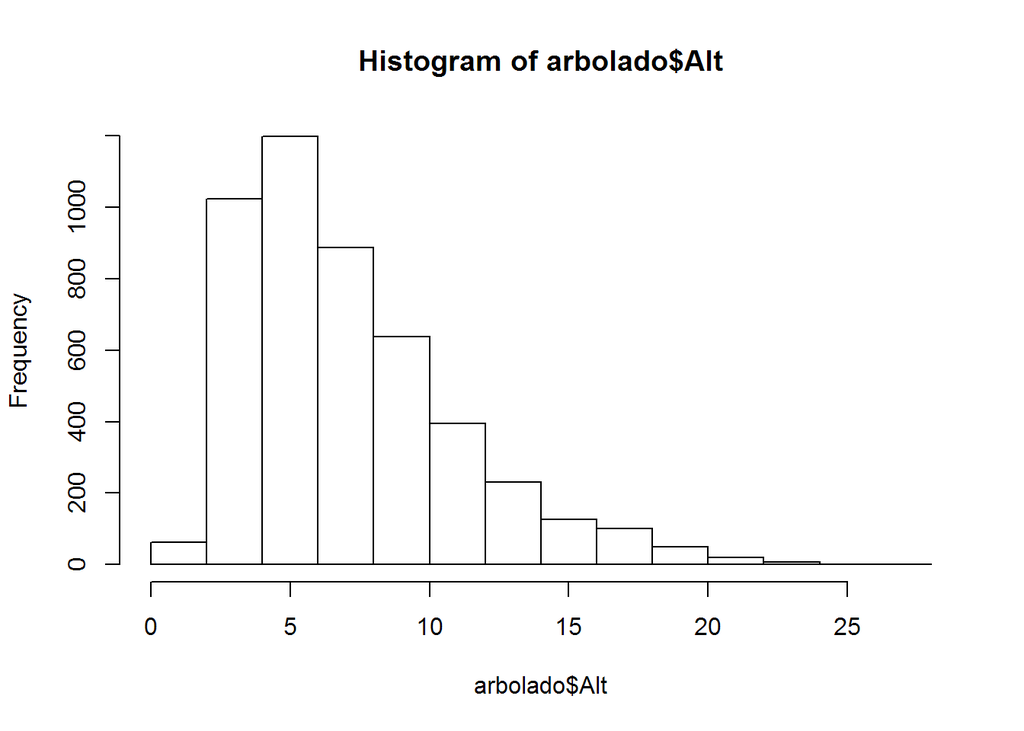

```r
hist(arbolado$Alt)
```

Las graficas pueden ser controlados por medio de una gran cantidad de parámetros.

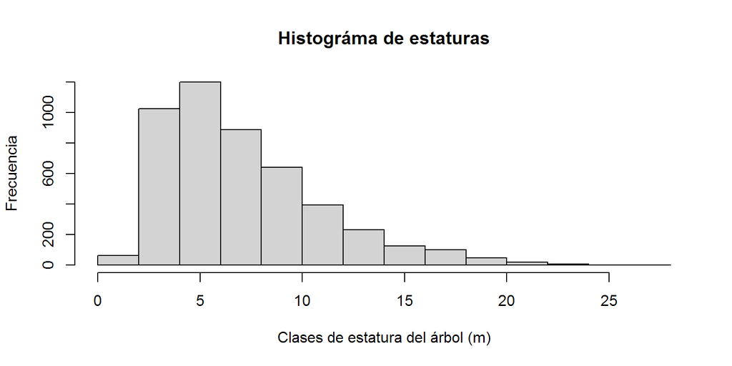

```r
hist(arbolado$Alt,
     col = "lightgray",
     xlab = "Clases de estatura del árbol (m)", ylab = "Frecuencia",
     main = "Histográma de estaturas")
```

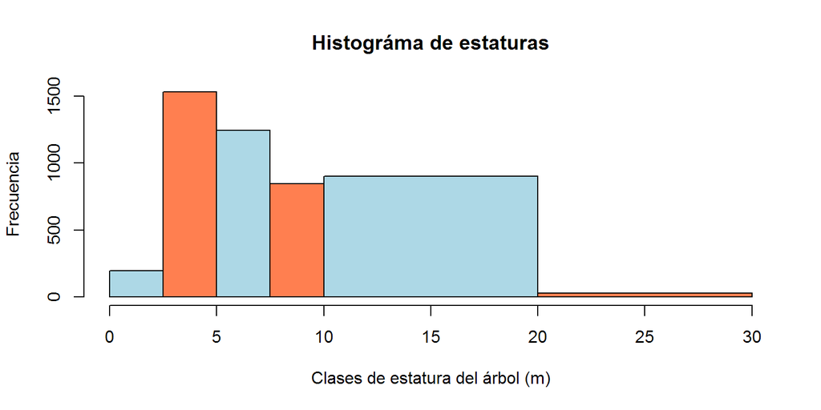

```r
H0 <- hist(arbolado$Alt,
     col = c("lightblue","coral"),
     xlab = "Clases de estatura del árbol (m)", ylab = "Frecuencia",
     main = "Histográma de estaturas",
     breaks = c(0,2.5,5,7.5,10,20,30), prob = FALSE)
```

```r
str(H0)
```

```
## List of 6
##  $ breaks  : num [1:7] 0 2.5 5 7.5 10 20 30
##  $ counts  : int [1:6] 196 1529 1242 844 900 28
##  $ density : num [1:6] 0.0165 0.1291 0.1048 0.0712 0.019 ...
##  $ mids    : num [1:6] 1.25 3.75 6.25 8.75 15 25
##  $ xname   : chr "arbolado$Alt"
##  $ equidist: logi FALSE
##  - attr(*, "class")= chr "histogram"
```

A continuar el día Jueves 20 de octubre del 2016